# Ford GoBike System Data Exploration

## Preliminary Wrangling

This data set includes information about individual rides made in a bike-sharing system covering the greater San Francisco Bay area.

```python
# import all packages and set plots to be embedded inline
import numpy as np
import pandas as pd
import matplotlib.pyplot as plt
import seaborn as sb

import glob
import os

%matplotlib inline
```

```python
#store list of all file locations
#all_files = glob.glob(os.path.join("*.csv"))

#load and union the dataset
#df = pd.concat((pd.read_csv(f) for f in all_files), ignore_index = True)

#write newly loaded data
#df.to_csv('master_file.csv', index=False)
```

```python
#Load in the dataset
df_bike=pd.read_csv('master_file.csv')
```

```python
# high-level overview of data shape and composition
df_bike.head()
```

|  | duration_sec | start_time | end_time | start_station_id | start_station_name | start_station_latitude | start_station_longitude | end_station_id | end_station_name | end_station_latitude | end_station_longitude | bike_id | user_type | member_birth_year | member_gender | bike_share_for_all_trip |
| --- | --- | --- | --- | --- | --- | --- | --- | --- | --- | --- | --- | --- | --- | --- | --- | --- |
| 0 | 598 | 2018-02-28 23:59:47.0970 | 2018-03-01 00:09:45.1870 | 284.0 | Yerba Buena Center for the Arts (Howard St at ... | 37.784872 | -122.400876 | 114.0 | Rhode Island St at 17th St | 37.764478 | -122.402570 | 1035 | Subscriber | 1988.0 | Male | No |
| 1 | 943 | 2018-02-28 23:21:16.4950 | 2018-02-28 23:36:59.9740 | 6.0 | The Embarcadero at Sansome St | 37.804770 | -122.403234 | 324.0 | Union Square (Powell St at Post St) | 37.788300 | -122.408531 | 1673 | Customer | 1987.0 | Male | No |
| 2 | 18587 | 2018-02-28 18:20:55.1900 | 2018-02-28 23:30:42.9250 | 93.0 | 4th St at Mission Bay Blvd S | 37.770407 | -122.391198 | 15.0 | San Francisco Ferry Building (Harry Bridges Pl... | 37.795392 | -122.394203 | 3498 | Customer | 1986.0 | Female | No |
| 3 | 18558 | 2018-02-28 18:20:53.6210 | 2018-02-28 23:30:12.4500 | 93.0 | 4th St at Mission Bay Blvd S | 37.770407 | -122.391198 | 15.0 | San Francisco Ferry Building (Harry Bridges Pl... | 37.795392 | -122.394203 | 3129 | Customer | 1981.0 | Male | No |
| 4 | 885 | 2018-02-28 23:15:12.8580 | 2018-02-28 23:29:58.6080 | 308.0 | San Pedro Square | 37.336802 | -121.894090 | 297.0 | Locust St at Grant St | 37.322980 | -121.887931 | 1839 | Subscriber | 1976.0 | Female | Yes |

```python
df_bike.info()
```

```
<class 'pandas.core.frame.DataFrame'>
RangeIndex: 1863721 entries, 0 to 1863720
Data columns (total 16 columns):
duration_sec               int64
start_time                 object
end_time                   object
start_station_id           float64
start_station_name         object
start_station_latitude     float64
start_station_longitude    float64
end_station_id             float64
end_station_name           object
end_station_latitude       float64
end_station_longitude      float64
bike_id                    int64
user_type                  object
member_birth_year          float64
member_gender              object
bike_share_for_all_trip    object
dtypes: float64(7), int64(2), object(7)
memory usage: 227.5+ MB
```

```python
df_bike.describe()
```

|  | duration_sec | start_station_id | start_station_latitude | start_station_longitude | end_station_id | end_station_latitude | end_station_longitude | bike_id | member_birth_year |
| --- | --- | --- | --- | --- | --- | --- | --- | --- | --- |
| count | 1.863721e+06 | 1.851950e+06 | 1.863721e+06 | 1.863721e+06 | 1.851950e+06 | 1.863721e+06 | 1.863721e+06 | 1.863721e+06 | 1.753003e+06 |
| mean | 8.573026e+02 | 1.196744e+02 | 3.776678e+01 | -1.223492e+02 | 1.181730e+02 | 3.776690e+01 | -1.223487e+02 | 2.296851e+03 | 1.983088e+03 |
| std | 2.370379e+03 | 1.003976e+02 | 1.057689e-01 | 1.654634e-01 | 1.004403e+02 | 1.056483e-01 | 1.650597e-01 | 1.287733e+03 | 1.044289e+01 |
| min | 6.100000e+01 | 3.000000e+00 | 3.726331e+01 | -1.224737e+02 | 3.000000e+00 | 3.726331e+01 | -1.224737e+02 | 1.100000e+01 | 1.881000e+03 |
| 25% | 3.500000e+02 | 3.300000e+01 | 3.777106e+01 | -1.224114e+02 | 3.000000e+01 | 3.777106e+01 | -1.224094e+02 | 1.225000e+03 | 1.978000e+03 |
| 50% | 5.560000e+02 | 8.900000e+01 | 3.778107e+01 | -1.223974e+02 | 8.800000e+01 | 3.778127e+01 | -1.223971e+02 | 2.338000e+03 | 1.985000e+03 |
| 75% | 8.720000e+02 | 1.860000e+02 | 3.779625e+01 | -1.222865e+02 | 1.830000e+02 | 3.779728e+01 | -1.222894e+02 | 3.333000e+03 | 1.991000e+03 |
| max | 8.636600e+04 | 3.810000e+02 | 4.551000e+01 | -7.357000e+01 | 3.810000e+02 | 4.551000e+01 | -7.357000e+01 | 6.234000e+03 | 2.000000e+03 |

```python
# check if duplicate exist
df_bike.duplicated().sum()
```

```
0
```

#### Quality issues

start time and end time are objects not a timestamps  
user type, gender and bike_share_for_all_trip can be set to category  
member birth year has dates prior to 1900  
we can calculate the age of the user  
we can further enhance the dataset with more details about the time like month, day, hour, weekday  
we can calculate the distance for rides between stations

### Data Cleaning

```python
df_clean=df_bike.copy()
```

1. Set appropriate data types for field

```python
#set dates for timestamps
df_clean.start_time=pd.to_datetime(df_clean.start_time)
df_clean.end_time=pd.to_datetime(df_clean.end_time)
```

```python
# set user type, gender and bike_share_for_all_trip to category
df_clean.user_type = df_clean.user_type.astype('category')
df_clean.member_gender = df_clean.member_gender.astype('category')
```

```python
#test
df_clean.info()
```

```
<class 'pandas.core.frame.DataFrame'>
RangeIndex: 1863721 entries, 0 to 1863720
Data columns (total 16 columns):
duration_sec               int64
start_time                 datetime64[ns]
end_time                   datetime64[ns]
start_station_id           float64
start_station_name         object
start_station_latitude     float64
start_station_longitude    float64
end_station_id             float64
end_station_name           object
end_station_latitude       float64
end_station_longitude      float64
bike_id                    int64
user_type                  category
member_birth_year          float64
member_gender              category
bike_share_for_all_trip    object
dtypes: category(2), datetime64[ns](2), float64(7), int64(2), object(3)
memory usage: 202.6+ MB
```

2.calculate the age of the member

```python
# substract the birth year from the current year
df_clean['Age']=2019-df_clean['member_birth_year']
```

```python
df_clean.head(5)
```

|  | duration_sec | start_time | end_time | start_station_id | start_station_name | start_station_latitude | start_station_longitude | end_station_id | end_station_name | end_station_latitude | end_station_longitude | bike_id | user_type | member_birth_year | member_gender | bike_share_for_all_trip | Age |
| --- | --- | --- | --- | --- | --- | --- | --- | --- | --- | --- | --- | --- | --- | --- | --- | --- | --- |
| 0 | 598 | 2018-02-28 23:59:47.097 | 2018-03-01 00:09:45.187 | 284.0 | Yerba Buena Center for the Arts (Howard St at ... | 37.784872 | -122.400876 | 114.0 | Rhode Island St at 17th St | 37.764478 | -122.402570 | 1035 | Subscriber | 1988.0 | Male | No | 31.0 |
| 1 | 943 | 2018-02-28 23:21:16.495 | 2018-02-28 23:36:59.974 | 6.0 | The Embarcadero at Sansome St | 37.804770 | -122.403234 | 324.0 | Union Square (Powell St at Post St) | 37.788300 | -122.408531 | 1673 | Customer | 1987.0 | Male | No | 32.0 |
| 2 | 18587 | 2018-02-28 18:20:55.190 | 2018-02-28 23:30:42.925 | 93.0 | 4th St at Mission Bay Blvd S | 37.770407 | -122.391198 | 15.0 | San Francisco Ferry Building (Harry Bridges Pl... | 37.795392 | -122.394203 | 3498 | Customer | 1986.0 | Female | No | 33.0 |
| 3 | 18558 | 2018-02-28 18:20:53.621 | 2018-02-28 23:30:12.450 | 93.0 | 4th St at Mission Bay Blvd S | 37.770407 | -122.391198 | 15.0 | San Francisco Ferry Building (Harry Bridges Pl... | 37.795392 | -122.394203 | 3129 | Customer | 1981.0 | Male | No | 38.0 |
| 4 | 885 | 2018-02-28 23:15:12.858 | 2018-02-28 23:29:58.608 | 308.0 | San Pedro Square | 37.336802 | -121.894090 | 297.0 | Locust St at Grant St | 37.322980 | -121.887931 | 1839 | Subscriber | 1976.0 | Female | Yes | 43.0 |

1. Enhance dataset with new date related fields

```python
# extract start time month number
df_clean['start_time_month']=df_clean['start_time'].dt.month.astype(int)
# extract start time weekdays
df_clean['start_time_weekday']=df_clean['start_time'].dt.strftime('%a')
# extract start time day
df_clean['start_time_day']=df_clean['start_time'].dt.day.astype(int)
# extract start time hour
df_clean['start_time_hour']=df_clean['start_time'].dt.hour
```

```python
df_clean.head()
```

|  | duration_sec | start_time | end_time | start_station_id | start_station_name | start_station_latitude | start_station_longitude | end_station_id | end_station_name | end_station_latitude | ... | bike_id | user_type | member_birth_year | member_gender | bike_share_for_all_trip | Age | start_time_month | start_time_weekday | start_time_day | start_time_hour |
| --- | --- | --- | --- | --- | --- | --- | --- | --- | --- | --- | --- | --- | --- | --- | --- | --- | --- | --- | --- | --- | --- |
| 0 | 598 | 2018-02-28 23:59:47.097 | 2018-03-01 00:09:45.187 | 284.0 | Yerba Buena Center for the Arts (Howard St at ... | 37.784872 | -122.400876 | 114.0 | Rhode Island St at 17th St | 37.764478 | ... | 1035 | Subscriber | 1988.0 | Male | No | 31.0 | 2 | Wed | 28 | 23 |
| 1 | 943 | 2018-02-28 23:21:16.495 | 2018-02-28 23:36:59.974 | 6.0 | The Embarcadero at Sansome St | 37.804770 | -122.403234 | 324.0 | Union Square (Powell St at Post St) | 37.788300 | ... | 1673 | Customer | 1987.0 | Male | No | 32.0 | 2 | Wed | 28 | 23 |
| 2 | 18587 | 2018-02-28 18:20:55.190 | 2018-02-28 23:30:42.925 | 93.0 | 4th St at Mission Bay Blvd S | 37.770407 | -122.391198 | 15.0 | San Francisco Ferry Building (Harry Bridges Pl... | 37.795392 | ... | 3498 | Customer | 1986.0 | Female | No | 33.0 | 2 | Wed | 28 | 18 |
| 3 | 18558 | 2018-02-28 18:20:53.621 | 2018-02-28 23:30:12.450 | 93.0 | 4th St at Mission Bay Blvd S | 37.770407 | -122.391198 | 15.0 | San Francisco Ferry Building (Harry Bridges Pl... | 37.795392 | ... | 3129 | Customer | 1981.0 | Male | No | 38.0 | 2 | Wed | 28 | 18 |
| 4 | 885 | 2018-02-28 23:15:12.858 | 2018-02-28 23:29:58.608 | 308.0 | San Pedro Square | 37.336802 | -121.894090 | 297.0 | Locust St at Grant St | 37.322980 | ... | 1839 | Subscriber | 1976.0 | Female | Yes | 43.0 | 2 | Wed | 28 | 23 |

5 rows × 21 columns

```python
df_clean.info()
```

```
<class 'pandas.core.frame.DataFrame'>
RangeIndex: 1863721 entries, 0 to 1863720
Data columns (total 21 columns):
duration_sec               int64
start_time                 datetime64[ns]
end_time                   datetime64[ns]
start_station_id           float64
start_station_name         object
start_station_latitude     float64
start_station_longitude    float64
end_station_id             float64
end_station_name           object
end_station_latitude       float64
end_station_longitude      float64
bike_id                    int64
user_type                  category
member_birth_year          float64
member_gender              category
bike_share_for_all_trip    object
Age                        float64
start_time_month           int64
start_time_weekday         object
start_time_day             int64
start_time_hour            int64
dtypes: category(2), datetime64[ns](2), float64(8), int64(5), object(4)
memory usage: 273.7+ MB
```

```python
df_clean.describe()
```

|  | duration_sec | start_station_id | start_station_latitude | start_station_longitude | end_station_id | end_station_latitude | end_station_longitude | bike_id | member_birth_year | Age | start_time_month | start_time_day | start_time_hour |
| --- | --- | --- | --- | --- | --- | --- | --- | --- | --- | --- | --- | --- | --- |
| count | 1.863721e+06 | 1.851950e+06 | 1.863721e+06 | 1.863721e+06 | 1.851950e+06 | 1.863721e+06 | 1.863721e+06 | 1.863721e+06 | 1.753003e+06 | 1.753003e+06 | 1.863721e+06 | 1.863721e+06 | 1.863721e+06 |
| mean | 8.573026e+02 | 1.196744e+02 | 3.776678e+01 | -1.223492e+02 | 1.181730e+02 | 3.776690e+01 | -1.223487e+02 | 2.296851e+03 | 1.983088e+03 | 3.591204e+01 | 6.928460e+00 | 1.571919e+01 | 1.351437e+01 |
| std | 2.370379e+03 | 1.003976e+02 | 1.057689e-01 | 1.654634e-01 | 1.004403e+02 | 1.056483e-01 | 1.650597e-01 | 1.287733e+03 | 1.044289e+01 | 1.044289e+01 | 3.118673e+00 | 8.786976e+00 | 4.742223e+00 |
| min | 6.100000e+01 | 3.000000e+00 | 3.726331e+01 | -1.224737e+02 | 3.000000e+00 | 3.726331e+01 | -1.224737e+02 | 1.100000e+01 | 1.881000e+03 | 1.900000e+01 | 1.000000e+00 | 1.000000e+00 | 0.000000e+00 |
| 25% | 3.500000e+02 | 3.300000e+01 | 3.777106e+01 | -1.224114e+02 | 3.000000e+01 | 3.777106e+01 | -1.224094e+02 | 1.225000e+03 | 1.978000e+03 | 2.800000e+01 | 5.000000e+00 | 8.000000e+00 | 9.000000e+00 |
| 50% | 5.560000e+02 | 8.900000e+01 | 3.778107e+01 | -1.223974e+02 | 8.800000e+01 | 3.778127e+01 | -1.223971e+02 | 2.338000e+03 | 1.985000e+03 | 3.400000e+01 | 7.000000e+00 | 1.600000e+01 | 1.400000e+01 |
| 75% | 8.720000e+02 | 1.860000e+02 | 3.779625e+01 | -1.222865e+02 | 1.830000e+02 | 3.779728e+01 | -1.222894e+02 | 3.333000e+03 | 1.991000e+03 | 4.100000e+01 | 1.000000e+01 | 2.300000e+01 | 1.700000e+01 |
| max | 8.636600e+04 | 3.810000e+02 | 4.551000e+01 | -7.357000e+01 | 3.810000e+02 | 4.551000e+01 | -7.357000e+01 | 6.234000e+03 | 2.000000e+03 | 1.380000e+02 | 1.200000e+01 | 3.100000e+01 | 2.300000e+01 |

4.Remove the outliers of age

```python
#find the 95 percentile of age
df_clean.Age.describe(percentiles=[.95])
```

```
count    1.753003e+06
mean     3.591204e+01
std      1.044289e+01
min      1.900000e+01
50%      3.400000e+01
95%      5.700000e+01
max      1.380000e+02
Name: Age, dtype: float64
```

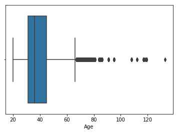

```python
#show the outliers in the boxplot
sb.boxplot(data=df_clean, x='Age')
```

```python
#keep the age <=60
df_clean=df_clean.query('Age<=60')
```

```python
# change age and birth year to integer
df_clean.Age = df_clean.Age.astype(int)
df_clean.member_birth_year = df_clean.member_birth_year.astype(int)
```

```python
df_clean.describe()
```

|  | duration_sec | start_station_id | start_station_latitude | start_station_longitude | end_station_id | end_station_latitude | end_station_longitude | bike_id | member_birth_year | Age | start_time_month | start_time_day | start_time_hour |
| --- | --- | --- | --- | --- | --- | --- | --- | --- | --- | --- | --- | --- | --- |
| count | 1.708250e+06 | 1.696859e+06 | 1.708250e+06 | 1.708250e+06 | 1.696859e+06 | 1.708250e+06 | 1.708250e+06 | 1.708250e+06 | 1.708250e+06 | 1.708250e+06 | 1.708250e+06 | 1.708250e+06 | 1.708250e+06 |
| mean | 7.770344e+02 | 1.204705e+02 | 3.776626e+01 | -1.223483e+02 | 1.189367e+02 | 3.776635e+01 | -1.223477e+02 | 2.307620e+03 | 1.983908e+03 | 3.509174e+01 | 6.985020e+00 | 1.572093e+01 | 1.351124e+01 |
| std | 1.985384e+03 | 1.001986e+02 | 1.068892e-01 | 1.695276e-01 | 1.002116e+02 | 1.067575e-01 | 1.691045e-01 | 1.293336e+03 | 9.114289e+00 | 9.114289e+00 | 3.112264e+00 | 8.782700e+00 | 4.769725e+00 |
| min | 6.100000e+01 | 3.000000e+00 | 3.726331e+01 | -1.224737e+02 | 3.000000e+00 | 3.726331e+01 | -1.224737e+02 | 1.100000e+01 | 1.959000e+03 | 1.900000e+01 | 1.000000e+00 | 1.000000e+00 | 0.000000e+00 |
| 25% | 3.450000e+02 | 3.600000e+01 | 3.777041e+01 | -1.224114e+02 | 3.000000e+01 | 3.777106e+01 | -1.224094e+02 | 1.230000e+03 | 1.979000e+03 | 2.800000e+01 | 5.000000e+00 | 8.000000e+00 | 9.000000e+00 |
| 50% | 5.430000e+02 | 8.900000e+01 | 3.778107e+01 | -1.223971e+02 | 8.900000e+01 | 3.778107e+01 | -1.223959e+02 | 2.348000e+03 | 1.986000e+03 | 3.300000e+01 | 7.000000e+00 | 1.600000e+01 | 1.400000e+01 |
| 75% | 8.400000e+02 | 1.860000e+02 | 3.779581e+01 | -1.222831e+02 | 1.860000e+02 | 3.779625e+01 | -1.222876e+02 | 3.346000e+03 | 1.991000e+03 | 4.000000e+01 | 1.000000e+01 | 2.300000e+01 | 1.700000e+01 |
| max | 8.628100e+04 | 3.810000e+02 | 4.551000e+01 | -7.357000e+01 | 3.810000e+02 | 4.551000e+01 | -7.357000e+01 | 6.234000e+03 | 2.000000e+03 | 6.000000e+01 | 1.200000e+01 | 3.100000e+01 | 2.300000e+01 |

```python
df_clean.info()
```

[output not shown]

```python
# save cleaned data
df_clean.to_csv('clean_master_file.csv', index=False)
```

### What is the structure of your dataset?

There are 1863721 entries in the dataset with 15 features (duration_sec, start_time, end_time, start_station_id, start_station_name, start_station_latitude,start_station_longitude, end_station_id, end_station_name, end_station_latitude, end_station_longitude, bike_id, user_type,member_birth_year, member_gender). Most variables are numeric in nature, but the variables start_station_name, end_station_name, user_type, member_gender are factor variables with the following levels.

user_type: Customer, Subscriber  
member_gender: Male, Female

The dataset was further enhanced with features that I may find neccessary to perform interesting analysis:

### What is/are the main feature(s) of interest in your dataset?

When are most trips taken in terms of time of day, day of the week, or month of the year?  
How long does the average trip take?  
Does the above depend on if a user is a subscriber or customer?  
Does the above depend on the age of the customer?

### What features in the dataset do you think will help support your investigation into your feature(s) of interest?

I expect that more trips will be taken in weekdays (for working) and holidays (for traveling). I also think that the subscriber has higher frequency of usage of the bike compare with customer.

## Univariate Exploration

I'll start by looking at the distribution of the main variable of interest: start_time

```
Text(0.5,1.03,'Monthly usage of the bike share system')
```

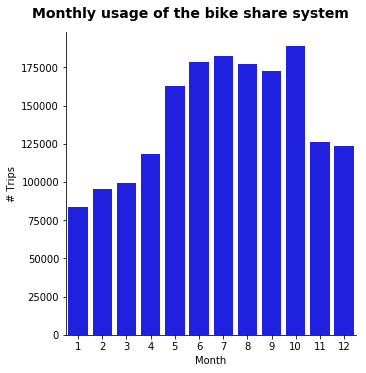

```python
#Monthly Usage of Bike
g = sb.catplot(data=df_clean, x='start_time_month', kind='count', color = 'blue')
g.set_axis_labels("Month", "# Trips")
g.fig.suptitle('Monthly usage of the bike share system',y=1.03, fontsize=14, fontweight='semibold')
```

Winter months are the worst for the bike sharing system most probably due to the weather conditions. The bike renting is high in demand between May and October, reaching its peak in October, followed by July.

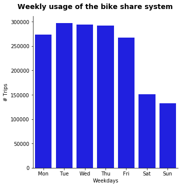

```python
# weekday usege of the bike
weekday = ['Mon', 'Tue', 'Wed', 'Thu', 'Fri', 'Sat', 'Sun']
g=sb.catplot(data=df_clean,x='start_time_weekday',kind='count',color='blue',order=weekday)
g.set_axis_labels("Weekdays", "# Trips")
g.fig.suptitle('Weekly usage of the bike share system', y=1.03, fontsize=14, fontweight='semibold');
```

The bike share system is mainly used during weekdays, with Tuesday - Thursday as the most popular days for bike rides. The system is most probably used as a daily work/school commute.

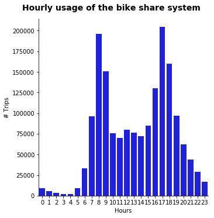

```python
# hourly usege of the bike sharing system

g = sb.catplot(data=df_clean, x='start_time_hour', kind='count', color = 'blue')
g.set_axis_labels("Hours", "# Trips")
g.fig.suptitle('Hourly usage of the bike share system', y=1.03, fontsize=14, fontweight='semibold');
```

The hourly distribution is bimodal, the system is used mainly around 8-9am and 5-6pm when people get to and gat back from work.

```
Text(0,0.5,'Count')
```

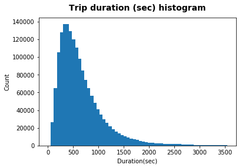

```python
# code for the (histogram) duration (sec) distribution per user type

bin_edges = np.arange(0, 3600,60)

plt.hist(data = df_clean, x = 'duration_sec', bins = bin_edges)

plt.title("Trip duration (sec) histogram", y=1.03, fontsize=14, fontweight='semibold')
plt.xlabel('Duration(sec)')
plt.ylabel('Count')
```

### Discuss the distribution(s) of your variable(s) of interest. Were there any unusual points? Did you need to perform any transformations?

The max duration (sec) is unusual, which lasted around 24h. And sicne most of the trip durations are less then 60 mins, I set the max range of the histogram to 3600 sec.

## Bivariate Exploration

In this section I will further explore the dataset by adding the customer type to the analysis.

```python
# Calculate the proportion of usage by customer type
customer=df_clean.query('user_type=="Customer"')['bike_id'].count()
subscriber=df_clean.query('user_type=="Subscriber"')['bike_id'].count()

customer_portion=customer/df_clean['bike_id'].count()
subscriber_portion=subscriber/df_clean['bike_id'].count()
```

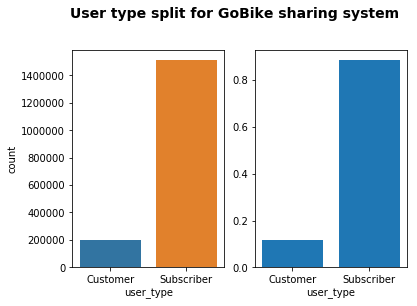

```python
plt.figure()

plt.subplot(1,2,1)
g=sb.countplot(data=df_clean,x='user_type')

plt.subplot(1,2,2)

size=[customer_portion,subscriber_portion]
labels=['Customer', 'Subscriber']
plt.bar(labels, size, )
plt.xlabel('user_type')

plt.suptitle('User type split for GoBike sharing system', y=1.03, fontsize=14, fontweight='semibold');
```

The bike sharing system is mainly used by subscribers (88%) than ocassional riders (12%).

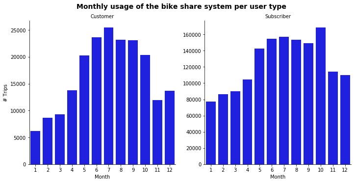

```python
# monthly usege of the bike sharing system per user type
g = sb.catplot(data=df_clean, x='start_time_month', col="user_type", kind='count',sharey=False,
            color = 'blue')
g.set_axis_labels("Month", "# Trips")
g.set_titles("{col_name}")
g.fig.suptitle('Monthly usage of the bike share system per user type', y=1.03, fontsize=14, fontweight='semibold');
```

Winter months are the worst for the bike sharing system for both groups what can be determined by the weather.

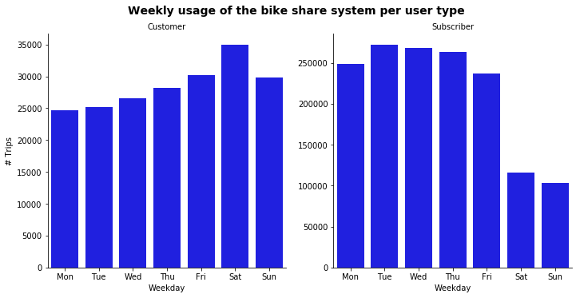

```python
# weekday usege of the bike sharing system per user type

weekday = ['Mon', 'Tue', 'Wed', 'Thu', 'Fri', 'Sat', 'Sun']
g = sb.catplot(data=df_clean, x='start_time_weekday', col="user_type", kind='count', sharey = False,
            color = 'blue', order = weekday)
g.set_axis_labels("Weekday", "# Trips")
g.set_titles("{col_name}")
g.fig.suptitle('Weekly usage of the bike share system per user type', y=1.03, fontsize=14, fontweight='semibold');
```

Customers are most probably occasional riders and tourist who use the bike sharing system on holiday or weekend trips. On the other hand, subscribers are most probably daily work/school commuters who use the system within a week.

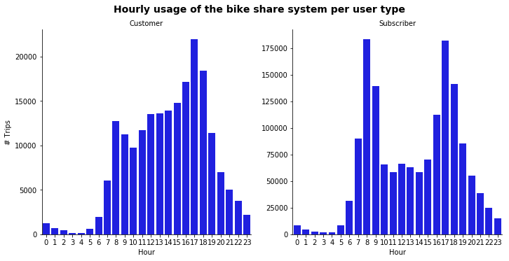

```python
# hourly usege of the bike sharing system per user type

g = sb.catplot(data=df_clean, x='start_time_hour', col="user_type", kind='count', sharey = False,
            color = 'blue')
g.set_axis_labels("Hour", "# Trips")
g.set_titles("{col_name}")
g.fig.suptitle('Hourly usage of the bike share system per user type', y=1.03, fontsize=14, fontweight='semibold');
```

There is also a different trend of when during the day bikes are rented most often. Customers use bikes mainly between 8 am - 7 pm, reaching the renting peak around 5pm. Subscribers on the other side use the system at around 8-9am and 5-6pm when they go and come back from work.

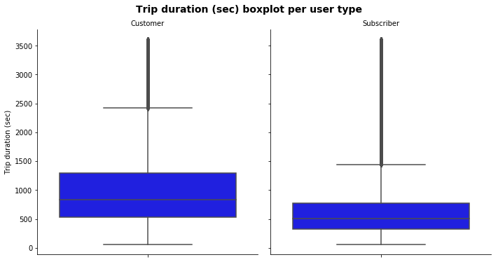

```python
# the (boxplot) duration (sec) distribution per user type

data = df_clean.query('duration_sec < 3600')
g = sb.catplot(data=data, y='duration_sec', col="user_type", kind='box',
            color = 'blue')
g.set_titles(col_template = '{col_name}')
g.set_axis_labels("", "Trip duration (sec)")
g.fig.suptitle('Trip duration (sec) boxplot per user type', y=1.03, fontsize=14, fontweight='semibold');
```

### Talk about some of the relationships you observed in this part of the investigation. How did the feature(s) of interest vary with other features in the dataset?

Adding the user type can show the different usage between customers and subscribers. Customers are casual riders, most probably tourists who rent bikes mainly in summertime (the peak in July), more often during weekends than weekdays and they rent bikes more often within the day rather than around commute hours (8-9am and 5-6pm). Subscribers are daily commuters, who also use the system around summertime, May-October (with the peak in October). They rent bikes more often during weekdays than weekends and mainly around the commute hours (8-9am and 5-6pm).

### Did you observe any interesting relationships between the other features (not the main feature(s) of interest)?

There is a difference in the trip duration between customers and subscribers. Customers trips are usually longer than for subscribers. customers prefer bike rides around weekends in summertime, so they can have longer trips around the area. Subscribers use the system mainly for commute purposes so they rather prefer quick rides.

## Multiviarate Exploration

```python
bins = [18, 30, 40, 50, 60]
labels = ['18-29', '30-39', '40-49', '50-60']
data['agerange'] = pd.cut(df_clean.Age, bins, labels = labels,include_lowest = True)
```

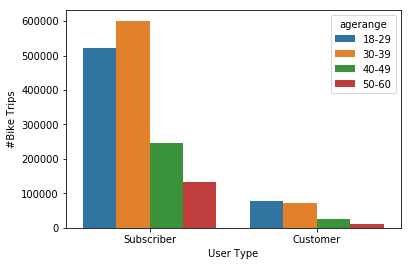

```python
g = sb.countplot(data=data, x="user_type", hue="agerange", order=df_clean.user_type.value_counts().index)
g.set_xlabel('User Type')
g.set_ylabel('#Bike Trips');
```

In general, people under 40 using the system more often than people in the age range of 40-60

[figure not shown]

```python
# monthly usege of the bike sharing system per user type and Age

g = sb.catplot(data=df_clean, x='start_time_month', col="user_type", hue="agerange", kind='count', sharey = False)
g.set_axis_labels("Month", "# Trips")
g._legend.set_title('Age')
g.set_titles("{col_name}")
g.fig.suptitle('Monthly usage of the bike share system per user type and age', y=1.03, fontsize=14, fontweight='semibold');
```

The trend is similar for the age groups: for customers, the highest demand is around summertime, reaching its peak in July; for subscribers, the highest demand is from May till October, reaching its peak in October.  
For customers, young people (18-29) use the system more frequently than the mid-ages (30-39) during the high demand season (Jun-Oct). While for the subscriber, the data is vice versa, mid-age use the system more than young people.

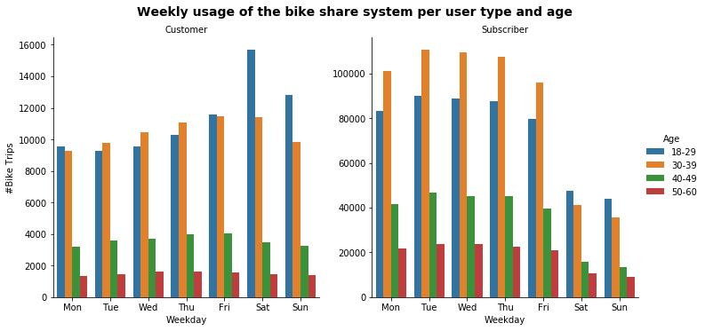

```python
# weekday usege of the bike sharing system per user type and Age

weekday = ['Mon', 'Tue', 'Wed', 'Thu', 'Fri', 'Sat', 'Sun']
g = sb.catplot(data=data, x='start_time_weekday', col="user_type", hue='agerange', kind='count', sharey = False,
                order = weekday)
g.set_axis_labels("Weekday", "#Bike Trips")
g._legend.set_title('Age')
g.set_titles("{col_name}")
g.fig.suptitle('Weekly usage of the bike share system per user type and age', y=1.03, fontsize=14, fontweight='semibold');
```

The usage trend is more evident in the weekly graph. For the customer, young people (18-29) are more likely to use the system on the weekend compared with other age groups. For the subscriber, mid-age people use the system more to commute.

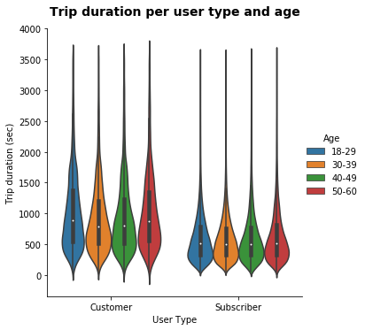

```python
# code for the (violinplot) duration (sec) distribution per user type and age

g = sb.catplot(data=data, x='user_type', y="duration_sec", hue="agerange", kind="violin")

g.set_axis_labels("User Type", "Trip duration (sec)")
g._legend.set_title('Age')
g.fig.suptitle('Trip duration per user type and age', y=1.03, fontsize=14, fontweight='semibold');
```

Here we can observe that the diffrence of trip duration among age groups is more visible for the customer than for the subscriber. For the customer, the youngest group (18-29) and the oldest group (50-60) have longer duration of bike usage compared with the other two groups.

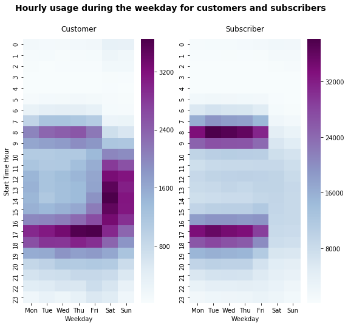

```python
# Setting the weekday order
df_clean['start_time_weekday'] = pd.Categorical(df_clean['start_time_weekday'],
                                                categories=['Mon','Tue','Wed','Thu','Fri','Sat', 'Sun'],
                                                ordered=True)
plt.figure(figsize=(9,8))
plt.suptitle('Hourly usage during the weekday for customers and subscribers', fontsize=14, fontweight='semibold')

# heatmap for customers
plt.subplot(1, 2, 1)
df_customer = df_clean.query('user_type == "Customer"').groupby(["start_time_hour", "start_time_weekday"])["bike_id"].size().reset_index()
df_customer = df_customer.pivot("start_time_hour", "start_time_weekday", "bike_id")
sb.heatmap(df_customer, cmap="BuPu")

plt.title("Customer", y=1.015)
plt.xlabel('Weekday')
plt.ylabel('Start Time Hour')

# heatmap for subscribers
plt.subplot(1, 2, 2)
df_subscriber = df_clean.query('user_type == "Subscriber"').groupby(["start_time_hour", "start_time_weekday"])["bike_id"].size().reset_index()
df_subscriber = df_subscriber.pivot("start_time_hour", "start_time_weekday", "bike_id")
sb.heatmap(df_subscriber, cmap="BuPu")

plt.title("Subscriber", y=1.015)
plt.xlabel('Weekday')
plt.ylabel('');
```

#### Customers use the bike sharing system more often on weekends:

weekdays: most bike rides are around 8-9am and 5-6pm with the peak on Fridays around 5pm  
weekends: most bike rides are between 10am - 8pm with the peak on Saturdays around 2pm

#### Subscribers use the bike sharing system mainly on weekdays:

weekdays: most bike rides are around 8-9am and 5-6pm with the peak on Tuesdays around 8am  
weekends: bikes are still rented but there is a significant drop in numbers of rented bikes throughout the entire weekends

### Were there any interesting or surprising interactions between features?

For the customer, young people (18-29) use the system more than the other age ranges on the weekend. For the subscriber, mid-age people (30-39) use the system more than young people within weekdays. Although the usage pattern of the subscriber is very similar to the customer on the weekend, the ratio is much less than the customer.